# Indel Signature InsDel_C

# InsDel_C

**Note**

In the 89-type classification, InsDel_C looks somewhat similar to InsDel13 in the prominence of deletions of Ts that are followed by A. However, the 83-type and 476-type classifications show that InsDel13 has deletions of from TT to T (e.g. ATTA -> ATA), while InsDel_C has deletions of single isolated Ts (e.g. ATA -> AA).

(corresponds to 83-type signature ID_C)

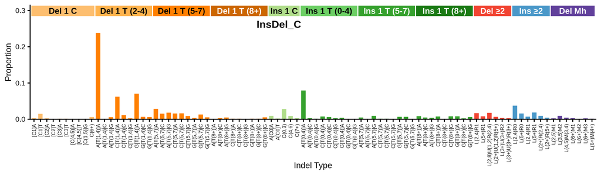

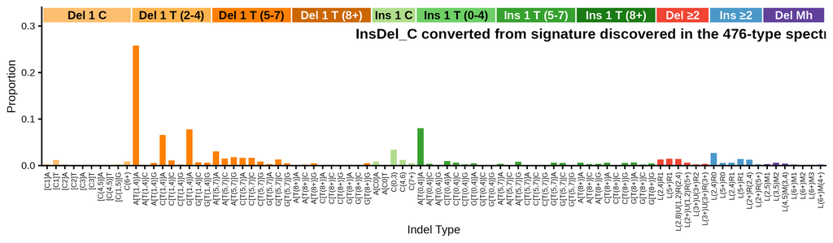

89-type spectrum of the linking tumor CPCT02010772T | cosine similarity to InsDel_C: 0.9713

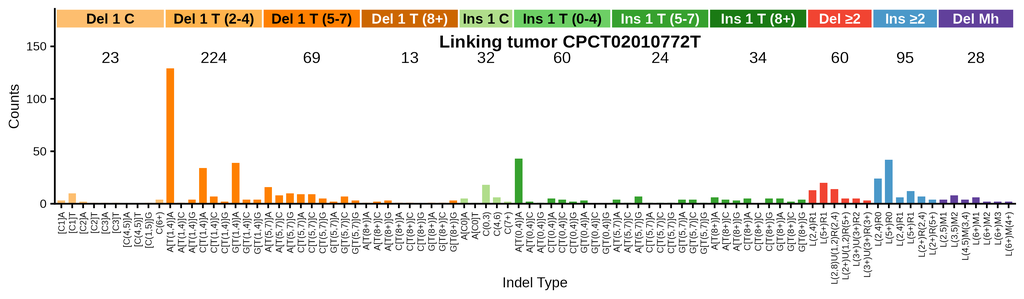

**Click to view decomposition of the linking tumor spectrum**

Partial mutation signature of CPCT02010772T due to InsDel_C

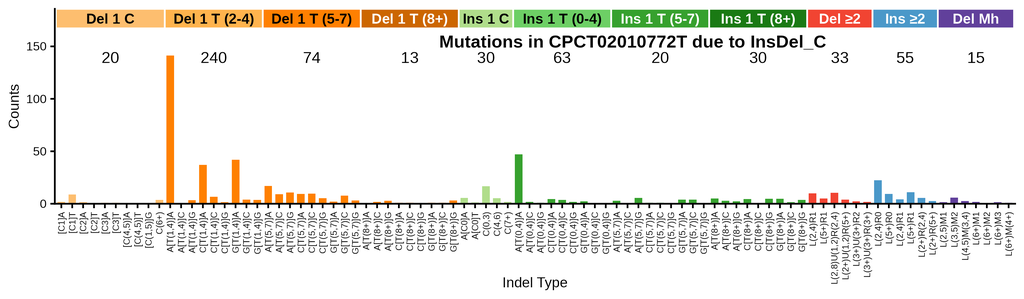

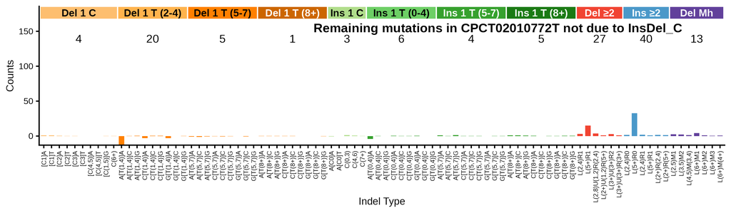

Max neg fraction (maximum allowed negative residual count as fraction of total): 0.04  
N subtract (mutation count assigned to signature): 593.1  
N residual (mutation count in residual “partial spectrum”): 68.9  
Total negative (sum of negative residual mutation counts): 29.6  
N negative channels (number of channels with negative residual): 26  
P(≥ total negative) (Monte Carlo estimated probability that negative-binomial-sampled spectra from the signature contributing N subtract mutations would produce a total negative count >= the observed Total negative; higher number means not surprising): 1.000

**Per-channel residual breakdown**

| Channel | Spectrum | Sig_Count | Residual | Sig_Prop |
| --- | --- | --- | --- | --- |
| [Del(C):R1]A | 3 | 1.9 | 1.1 | 0.00314 |
| [Del(C):R1]T | 10 | 8.9 | 1.1 | 0.01505 |
| [Del(C):R2]A | 2 | 1.6 | 0.4 | 0.00269 |
| [Del(C):R2]T | 1 | 0.7 | 0.3 | 0.00114 |
| [Del(C):R3]A | 1 | 0.8 | 0.2 | 0.00139 |
| [Del(C):R3]T | 1 | 1.0 | 0 | 0.00171 |
| [Del(C):R(4,5)]A | 0 | 0.2 | -0.2 | 0.00036 |
| [Del(C):R(4,5)]T | 0 | 0.2 | -0.2 | 0.00032 |
| [Del(C):R(1,5)]G | 1 | 0.8 | 0.2 | 0.00136 |
| Del(C):R(6,9) | 4 | 3.7 | 0.3 | 0.00616 |
| A[Del(T):R(1,4)]A | 129 | 141.4 | -12.4 | 0.23837 |
| A[Del(T):R(1,4)]C | 1 | 0.8 | 0.2 | 0.00135 |
| A[Del(T):R(1,4)]G | 4 | 3.5 | 0.5 | 0.00587 |
| C[Del(T):R(1,4)]A | 34 | 37.1 | -3.1 | 0.06251 |
| C[Del(T):R(1,4)]C | 7 | 6.6 | 0.4 | 0.01114 |
| C[Del(T):R(1,4)]G | 2 | 1.4 | 0.6 | 0.00234 |
| G[Del(T):R(1,4)]A | 39 | 41.9 | -2.9 | 0.07056 |
| G[Del(T):R(1,4)]C | 4 | 4.1 | -0.1 | 0.00683 |
| G[Del(T):R(1,4)]G | 4 | 3.8 | 0.2 | 0.00633 |
| A[Del(T):R(5,7)]A | 16 | 17.1 | -1.1 | 0.02875 |
| A[Del(T):R(5,7)]C | 8 | 9.2 | -1.2 | 0.01550 |
| A[Del(T):R(5,7)]G | 10 | 10.7 | -0.7 | 0.01796 |
| C[Del(T):R(5,7)]A | 9 | 9.4 | -0.4 | 0.01592 |
| C[Del(T):R(5,7)]C | 9 | 9.5 | -0.5 | 0.01610 |
| C[Del(T):R(5,7)]G | 5 | 5.3 | -0.3 | 0.00892 |
| G[Del(T):R(5,7)]A | 2 | 2.1 | -0.1 | 0.00350 |
| G[Del(T):R(5,7)]C | 7 | 7.7 | -0.7 | 0.01290 |
| G[Del(T):R(5,7)]G | 3 | 3.0 | 0 | 0.00511 |
| A[Del(T):R(8,)]A | 1 | 0.8 | 0.2 | 0.00133 |
| A[Del(T):R(8,)]C | 2 | 1.8 | 0.2 | 0.00301 |

[output cut: 59 more lines]

**Click to view similar signatures from Koh et al.**

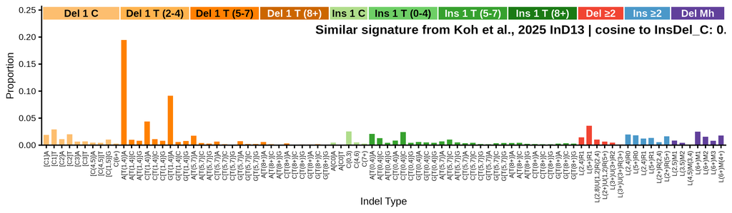

## 476-type representations corresponding to InsDel_C

Extracted 476-type signature corresponding to InsDel_C

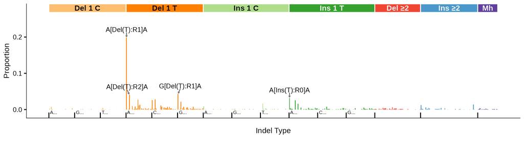

476-type spectrum of the linking tumor CPCT02010772T; cosine similarity to the extracted 476-type signature is 0.9583

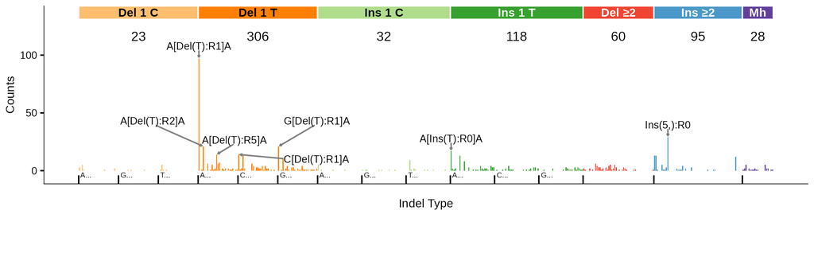

## 83-type signature corresponding to InsDel_C (ID_C)

**Note**

WARNING: The 83-type ID_C extraction seems to have excluded T deletions and insertions in most contexts, leaving only isolated T deletions (nonT)T(nonT) -> (nonT)(nonT). The other T deletions and insertions were detected in extractions in the 89-type and 476-type classifications.

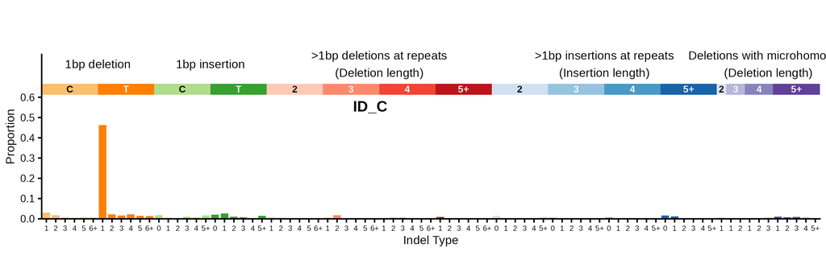

83-type signature converted from signature discovered in the 476-type spectra (using bipartite matching optimization) | cosine similarity to ID_C: 0.8878

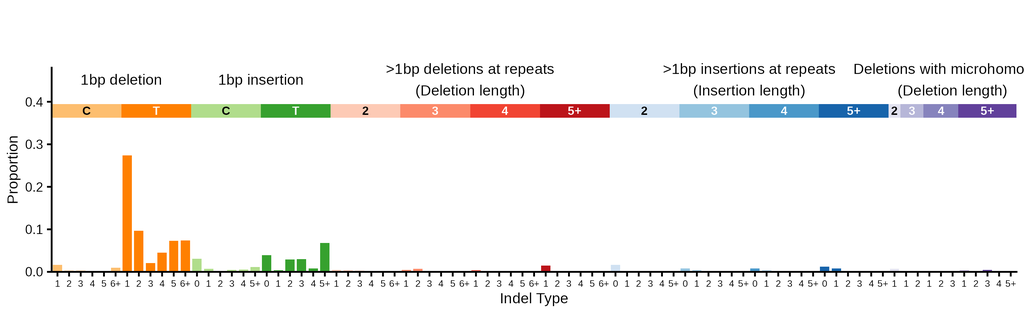

**Click to see flow diagrams: 476-type to 83-type collapse**

These Sankey diagrams show how the 476-type mutation categories are redistributed to 83-type categories using bipartite matching. We only show the diagrams for insertions or deletions of > 1 base because it is for these indels that 476-type categories map to > 1 83-type category.

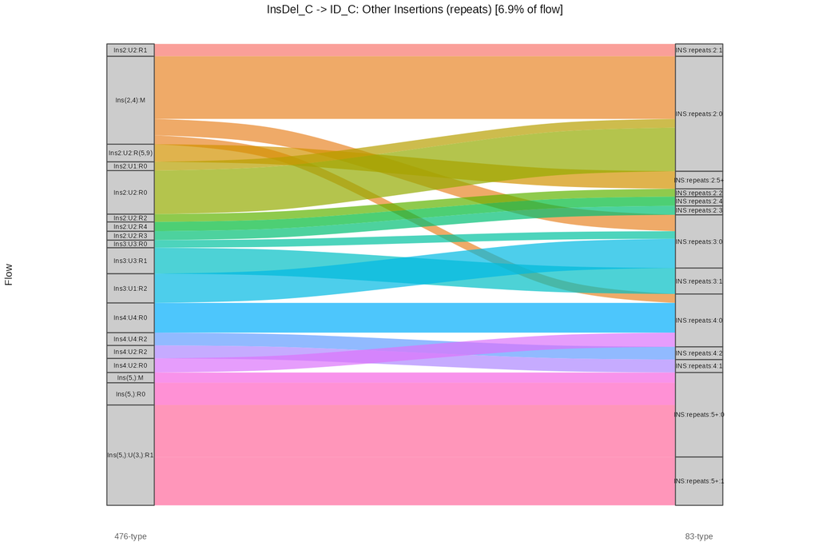

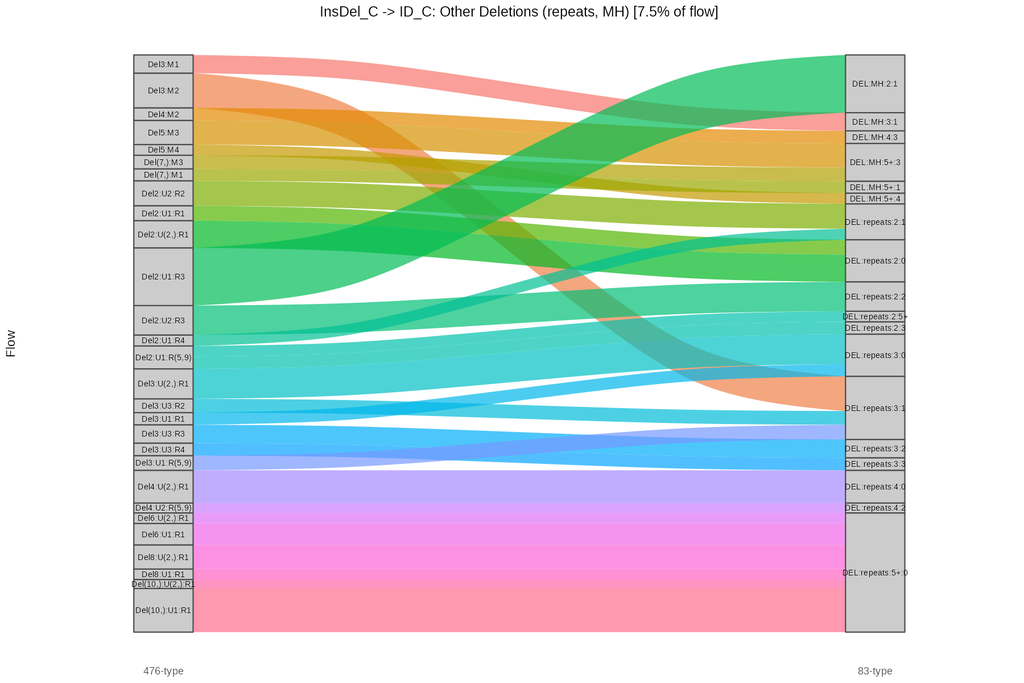

83-type spectrum of the linking tumor CPCT02010772T | cosine similarity to ID_C: 0.8267

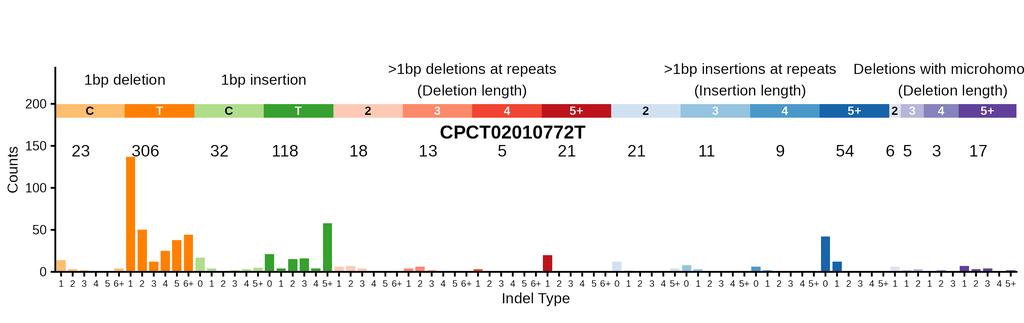